# Project Description

**• DOMAIN:** Telecom

**• CONTEXT:** A telecom company wants to use their historical customer data to predict behaviour to retain customers. You can analyse all relevant customer data and develop focused customer retention programs.

**• DATA DESCRIPTION:** Each row represents a customer, each column contains customer’s attributes described on the column Metadata.The data set includes information about:

- Customers who left within the last month – the column is called Churn
- Services that each customer has signed up for – phone, multiple lines, internet, online security, online backup,device protection, tech support, and streaming TV and movies
- Customer account information – how long they’ve been a customer, contract, payment method, paperless billing, monthly charges, and total charges
- Demographic info about customers – gender, age range, and if they have partners and dependents

**• PROJECT OBJECTIVE:** Build a model that will help to identify the potential customers who have a higher probability to churn. This help the company to understand the pinpoints and patterns of customer churn and will increase the focus on strategising customer retention.

### 1. Import and warehouse data :

```python
# importing all the required packages
import numpy as np
import pandas as pd
import matplotlib as mpl
import matplotlib.pyplot as plt
import seaborn as sns
import time
from scipy.stats import f_oneway
from scipy.stats import chi2_contingency
from sklearn.preprocessing import OneHotEncoder,LabelEncoder,MinMaxScaler
from sklearn.model_selection import train_test_split,GridSearchCV
from sklearn.metrics import classification_report,accuracy_score,recall_score,f1_score,precision_score


from sklearn.ensemble import RandomForestClassifier
from sklearn.svm import SVC
from xgboost import XGBClassifier
from sklearn.linear_model import LogisticRegression
from sklearn.naive_bayes import GaussianNB
from sklearn.tree import DecisionTreeClassifier
from sklearn.ensemble import BaggingClassifier
from sklearn.ensemble import AdaBoostClassifier
from sklearn.neighbors import KNeighborsClassifier
from sklearn.ensemble import GradientBoostingClassifier
from sklearn.ensemble import VotingClassifier
from catboost import CatBoostClassifier
from lightgbm import LGBMClassifier

import warnings
warnings.filterwarnings("ignore")

from imblearn.over_sampling import SMOTE


%matplotlib inline

plt.rcParams['figure.figsize'] = (11,8)
```

```python
#import and loading data

data1 = pd.read_csv('TelcomCustomer-Churn_1.csv')
data2 = pd.read_csv('TelcomCustomer-Churn_2.csv')
```

```python
data1.head()
```

|  | customerID | gender | SeniorCitizen | Partner | Dependents | tenure | PhoneService | MultipleLines | InternetService | OnlineSecurity |
| --- | --- | --- | --- | --- | --- | --- | --- | --- | --- | --- |
| 0 | 7590-VHVEG | Female | 0 | Yes | No | 1 | No | No phone service | DSL | No |
| 1 | 5575-GNVDE | Male | 0 | No | No | 34 | Yes | No | DSL | Yes |
| 2 | 3668-QPYBK | Male | 0 | No | No | 2 | Yes | No | DSL | Yes |
| 3 | 7795-CFOCW | Male | 0 | No | No | 45 | No | No phone service | DSL | Yes |
| 4 | 9237-HQITU | Female | 0 | No | No | 2 | Yes | No | Fiber optic | No |

```python
print('Shape of dataset 1 is ',data1.shape)
print( 'Number of missing data:\n {}'.format(data1.isnull().sum()))
```

```
Shape of dataset 1 is  (7043, 10)
Number of missing data:
 customerID         0
gender             0
SeniorCitizen      0
Partner            0
Dependents         0
tenure             0
PhoneService       0
MultipleLines      0
InternetService    0
OnlineSecurity     0
dtype: int64
```

```python
data2.head()
```

|  | OnlineBackup | DeviceProtection | TechSupport | StreamingTV | StreamingMovies | Contract | PaperlessBilling | PaymentMethod | MonthlyCharges | TotalCharges | Churn |
| --- | --- | --- | --- | --- | --- | --- | --- | --- | --- | --- | --- |
| 0 | Yes | No | No | No | No | Month-to-month | Yes | Electronic check | 29.85 | 29.85 | No |
| 1 | No | Yes | No | No | No | One year | No | Mailed check | 56.95 | 1889.5 | No |
| 2 | Yes | No | No | No | No | Month-to-month | Yes | Mailed check | 53.85 | 108.15 | Yes |
| 3 | No | Yes | Yes | No | No | One year | No | Bank transfer (automatic) | 42.30 | 1840.75 | No |
| 4 | No | No | No | No | No | Month-to-month | Yes | Electronic check | 70.70 | 151.65 | Yes |

```python
print('Shape of dataset 1 is ',data2.shape)
print( 'Number of missing data:\n {}'.format(data2 .isnull().sum()))
```

```
Shape of dataset 1 is  (7043, 11)
Number of missing data:
 OnlineBackup        0
DeviceProtection    0
TechSupport         0
StreamingTV         0
StreamingMovies     0
Contract            0
PaperlessBilling    0
PaymentMethod       0
MonthlyCharges      0
TotalCharges        0
Churn               0
dtype: int64
```

```python
# Merging  the Dastasets
# number of rows of both sets are equal and names of cols are different so we will perform concatination across columns[axis =1]

data3 = pd.concat([data1,data2],axis = 1)
data3.head()
```

|  | customerID | gender | SeniorCitizen | Partner | Dependents | tenure | PhoneService | MultipleLines | InternetService | OnlineSecurity | ... | DeviceProtection | TechSupport | StreamingTV | StreamingMovies | Contract | PaperlessBilling | PaymentMethod | MonthlyCharges | TotalCharges | Churn |
| --- | --- | --- | --- | --- | --- | --- | --- | --- | --- | --- | --- | --- | --- | --- | --- | --- | --- | --- | --- | --- | --- |
| 0 | 7590-VHVEG | Female | 0 | Yes | No | 1 | No | No phone service | DSL | No | ... | No | No | No | No | Month-to-month | Yes | Electronic check | 29.85 | 29.85 | No |
| 1 | 5575-GNVDE | Male | 0 | No | No | 34 | Yes | No | DSL | Yes | ... | Yes | No | No | No | One year | No | Mailed check | 56.95 | 1889.5 | No |
| 2 | 3668-QPYBK | Male | 0 | No | No | 2 | Yes | No | DSL | Yes | ... | No | No | No | No | Month-to-month | Yes | Mailed check | 53.85 | 108.15 | Yes |
| 3 | 7795-CFOCW | Male | 0 | No | No | 45 | No | No phone service | DSL | Yes | ... | Yes | Yes | No | No | One year | No | Bank transfer (automatic) | 42.30 | 1840.75 | No |
| 4 | 9237-HQITU | Female | 0 | No | No | 2 | Yes | No | Fiber optic | No | ... | No | No | No | No | Month-to-month | Yes | Electronic check | 70.70 | 151.65 | Yes |

5 rows × 21 columns

```python
print('Shape of dataset 1 is ',data3.shape)
print( 'Number of missing data:\n {}'.format(data3 .isnull().sum()))
```

```
Shape of dataset 1 is  (7043, 21)
Number of missing data:
 customerID          0
gender              0
SeniorCitizen       0
Partner             0
Dependents          0
tenure              0
PhoneService        0
MultipleLines       0
InternetService     0
OnlineSecurity      0
OnlineBackup        0
DeviceProtection    0
TechSupport         0
StreamingTV         0
StreamingMovies     0
Contract            0
PaperlessBilling    0
PaymentMethod       0
MonthlyCharges      0
TotalCharges        0
Churn               0
dtype: int64
```

```python
data3.info()
```

```
<class 'pandas.core.frame.DataFrame'>
RangeIndex: 7043 entries, 0 to 7042
Data columns (total 21 columns):
 #   Column            Non-Null Count  Dtype
---  ------            --------------  -----
 0   customerID        7043 non-null   object
 1   gender            7043 non-null   object
 2   SeniorCitizen     7043 non-null   int64
 3   Partner           7043 non-null   object
 4   Dependents        7043 non-null   object
 5   tenure            7043 non-null   int64
 6   PhoneService      7043 non-null   object
 7   MultipleLines     7043 non-null   object
 8   InternetService   7043 non-null   object
 9   OnlineSecurity    7043 non-null   object
 10  OnlineBackup      7043 non-null   object
 11  DeviceProtection  7043 non-null   object
 12  TechSupport       7043 non-null   object
 13  StreamingTV       7043 non-null   object
 14  StreamingMovies   7043 non-null   object
 15  Contract          7043 non-null   object
 16  PaperlessBilling  7043 non-null   object
 17  PaymentMethod     7043 non-null   object
 18  MonthlyCharges    7043 non-null   float64
 19  TotalCharges      7043 non-null   object
 20  Churn             7043 non-null   object
dtypes: float64(1), int64(2), object(18)
memory usage: 1.1+ MB
```

```python
data3.describe()
```

|  | SeniorCitizen | tenure | MonthlyCharges |
| --- | --- | --- | --- |
| count | 7043.000000 | 7043.000000 | 7043.000000 |
| mean | 0.162147 | 32.371149 | 64.761692 |
| std | 0.368612 | 24.559481 | 30.090047 |
| min | 0.000000 | 0.000000 | 18.250000 |
| 25% | 0.000000 | 9.000000 | 35.500000 |
| 50% | 0.000000 | 29.000000 | 70.350000 |
| 75% | 0.000000 | 55.000000 | 89.850000 |
| max | 1.000000 | 72.000000 | 118.750000 |

### 2. Data cleansing:

###### 1.Printing All columns unique values:

```python
for x in data3.columns:
    print('{} : {}'.format(x,data3[x].unique()))
    print('-'*50)
```

```
customerID : ['7590-VHVEG' '5575-GNVDE' '3668-QPYBK' ... '4801-JZAZL' '8361-LTMKD'
 '3186-AJIEK']
--------------------------------------------------
gender : ['Female' 'Male']
--------------------------------------------------
SeniorCitizen : [0 1]
--------------------------------------------------
Partner : ['Yes' 'No']
--------------------------------------------------
Dependents : ['No' 'Yes']
--------------------------------------------------
tenure : [ 1 34  2 45  8 22 10 28 62 13 16 58 49 25 69 52 71 21 12 30 47 72 17 27
  5 46 11 70 63 43 15 60 18 66  9  3 31 50 64 56  7 42 35 48 29 65 38 68
 32 55 37 36 41  6  4 33 67 23 57 61 14 20 53 40 59 24 44 19 54 51 26  0
 39]
--------------------------------------------------
PhoneService : ['No' 'Yes']
--------------------------------------------------
MultipleLines : ['No phone service' 'No' 'Yes']
--------------------------------------------------
InternetService : ['DSL' 'Fiber optic' 'No']
--------------------------------------------------
OnlineSecurity : ['No' 'Yes' 'No internet service']
--------------------------------------------------
OnlineBackup : ['Yes' 'No' 'No internet service']
--------------------------------------------------
DeviceProtection : ['No' 'Yes' 'No internet service']
--------------------------------------------------
TechSupport : ['No' 'Yes' 'No internet service']
--------------------------------------------------
StreamingTV : ['No' 'Yes' 'No internet service']
--------------------------------------------------
StreamingMovies : ['No' 'Yes' 'No internet service']
--------------------------------------------------
Contract : ['Month-to-month' 'One year' 'Two year']
--------------------------------------------------
PaperlessBilling : ['Yes' 'No']
--------------------------------------------------
PaymentMethod : ['Electronic check' 'Mailed check' 'Bank transfer (automatic)'
 'Credit card (automatic)']
--------------------------------------------------
MonthlyCharges : [29.85 56.95 53.85 ... 63.1  44.2  78.7 ]
--------------------------------------------------
TotalCharges : ['29.85' '1889.5' '108.15' ... '346.45' '306.6' '6844.5']
--------------------------------------------------
Churn : ['No' 'Yes']
--------------------------------------------------
```

###### 2.Handling missing values in 'TotalCharges' and 'MonthlyCharges'

1. First we need to convert String features into into float which they are suppose to be
2. Then we check for missing values or empty values and fill them with mean
3. Then we convert cateroical typre columns into caterogy
4. We remove customer id from tha data

```python
# checking for missing values or empty strings in totalcharges and replacing them with np.nan
for i in range(len(data3['TotalCharges'])):
    x = data3.loc[i,'TotalCharges']
    if(len(x) <2 ):
        data3.loc[i,'TotalCharges'] = np.nan
```

###### 2.Converting object datatypes into Integer, float and categorical datatypes

```python
# we can se that 'TotalCharges' and 'MonthlyCharges' are float but Entered as object type
data3['TotalCharges'] = pd.to_numeric(data3['TotalCharges'])
data3['MonthlyCharges'] = pd.to_numeric(data3['MonthlyCharges'])
print(data3['TotalCharges'].dtype)
print(data3['MonthlyCharges'].dtype)
```

```
float64
float64
```

```python
data3['TotalCharges'].isnull().sum()
```

```
11
```

```python
# handling missing Values in 'TotalCharges' after coverting into float type
data3['TotalCharges'] = data3['TotalCharges'].fillna(data3['TotalCharges'].mean())
data3['TotalCharges'].isnull().sum()
```

```
0
```

Now we can see there aare 11 null values in Total charges

```python
# handling missing Values in 'MonthlyCharges' after coverting into float type
data3['MonthlyCharges'].isnull().sum()
```

```
0
```

```python
# convert caterical feateatures
num_cols = [i for i in data3.columns if data3[i].dtype != 'O']
cat_cols = [i for i in data3.columns if data3[i].dtype == 'O']

for x in cat_cols:
    data3[x] = data3[x].astype('category')
```

```python
for x in cat_cols:
    print(data3[x].dtype)
```

```
category
category
category
category
category
category
category
category
category
category
category
category
category
category
category
category
category
```

```python
# remoove customer id from the data
data3.drop('customerID',axis = 1,inplace = True)
cat_cols = cat_cols[1:]
```

```python
cat_cols
```

```
['gender',
 'Partner',
 'Dependents',
 'PhoneService',
 'MultipleLines',
 'InternetService',
 'OnlineSecurity',
 'OnlineBackup',
 'DeviceProtection',
 'TechSupport',
 'StreamingTV',
 'StreamingMovies',
 'Contract',
 'PaperlessBilling',
 'PaymentMethod',
 'Churn']
```

### 3. Data analysis & visualisation

#### 1. Statistical Analysis

**Note:** Both the One-Way ANOVA and the Independent Samples t Test can compare the means for two groups. However, only the One-Way ANOVA can compare the means across three or more groups

```python
# 1. one-way anova
# H0 : All the means are Equal
# Ha : All the means are not equal
def one_way_anova(data3):
    fn = (data3['Churn'] == 'No')
    fs = (data3['Churn'] == 'Yes')

    stats_df = pd.DataFrame({},columns =['Result','Outcome'])
    for c in num_cols:
        samplen = data3.loc[fn,c]
        samples = data3.loc[fs,c]
        stats,p_val = f_oneway(samplen,samples)
        if (p_val < 0.05):
            df = pd.DataFrame({'Result':['means are not equal'],
                            'Outcome':['reject null hypothesis']})

            stats_df = pd.concat([stats_df,df],axis = 0)

        else:
            df = pd.DataFrame({'Result':['mean equal'],
                              'Outcome':['fail to reject null hypothesis']})

            stats_df = pd.concat([stats_df,df],axis = 0)

    stats_df.index = num_cols

    return stats_df
```

```python
stats_df = one_way_anova(data3)
stats_df
```

|  | Result | Outcome |
| --- | --- | --- |
| SeniorCitizen | means are not equal | reject null hypothesis |
| tenure | means are not equal | reject null hypothesis |
| MonthlyCharges | means are not equal | reject null hypothesis |
| TotalCharges | means are not equal | reject null hypothesis |

```python
#The Pearson’s chi-squared statistical hypothesis is an example of a test for independence between categorical variables.
# H₀: The two categorical variables have no relationship [dependent and independent]
# H₁: There is a relationship between two categorical variables [dependent and independent]
def chi2_test(data3):

    chi_df = pd.DataFrame({},columns =['Result','Outcome'])

    for c in cat_cols:
        crosstab=pd.crosstab(data3['Churn'],data3[c])

        chi,p_val,dof,expected=chi2_contingency(crosstab)
        if (p_val < 0.05):
            df = pd.DataFrame({'Result':['have no relationship with Churn'],
                            'Outcome':['reject null hypothesis']})

            chi_df = pd.concat([chi_df,df],axis = 0)

        else:
            df = pd.DataFrame({'Result':[' have relationship with Chrun'],
                              'Outcome':['fail to reject null hypothesis']})

            chi_df = pd.concat([chi_df,df],axis = 0)

    chi_df.index = cat_cols

    return chi_df
```

```python
chi2_test(data3)
```

[output not shown]

#### 2. Visualisation

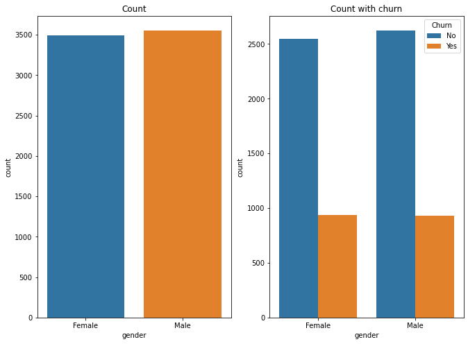

```python
c = cat_cols
plt.subplot(1,2,1)
sns.countplot(x = c[0],data = data3)
plt.title('Count')

plt.subplot(1,2,2)
sns.countplot(x = c[0],data = data3,hue = 'Churn')
plt.title('Count with churn')
plt.show()
```

**Note:** both male and female has approx equal ratio in churing

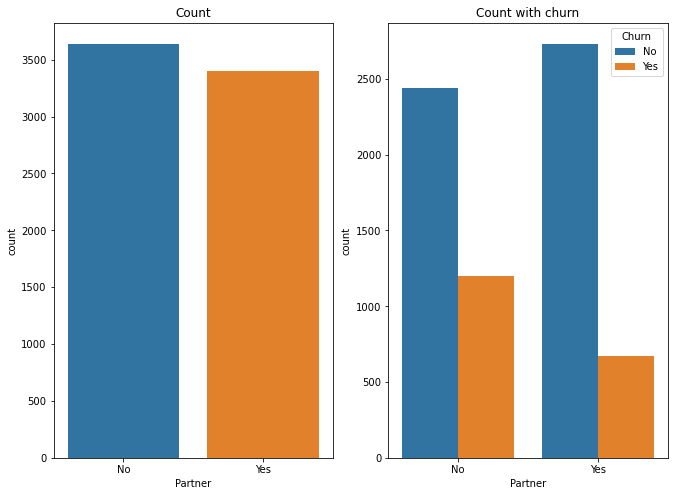

```python
plt.subplot(1,2,1)
sns.countplot(x = c[1],data = data3)
plt.title('Count')

plt.subplot(1,2,2)
sns.countplot(x = c[1],data = data3,hue = 'Churn')
plt.title('Count with churn')
plt.show()
```

**Note:** Those dont have patters have churned more than those dont have

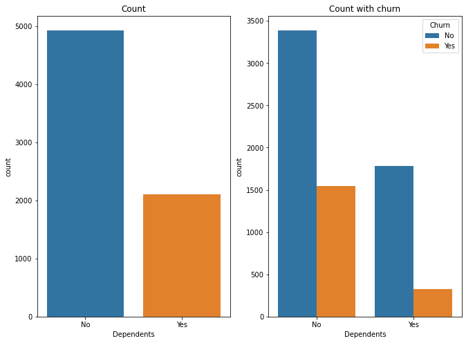

```python
plt.subplot(1,2,1)
sns.countplot(x = c[2],data = data3)
plt.title('Count')

plt.subplot(1,2,2)
sns.countplot(x = c[2],data = data3,hue = 'Churn')
plt.title('Count with churn')
plt.show()
```

**Note:** People who doesnt have dependenices have churned more than those who dont

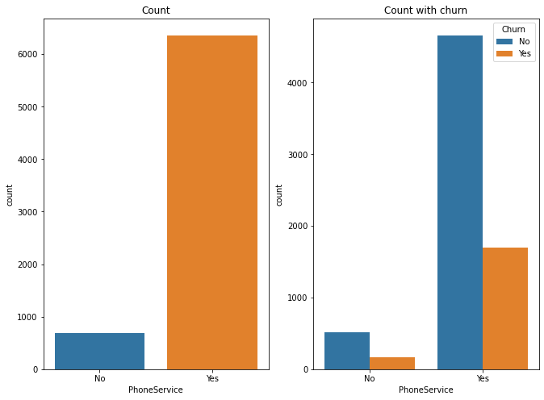

```python
plt.subplot(1,2,1)
sns.countplot(x = c[3],data = data3)
plt.title('Count')

plt.subplot(1,2,2)
sns.countplot(x = c[3],data = data3,hue = 'Churn')
plt.title('Count with churn')
plt.show()
```

**Note:** People who has phone services have churned more than people those who dont

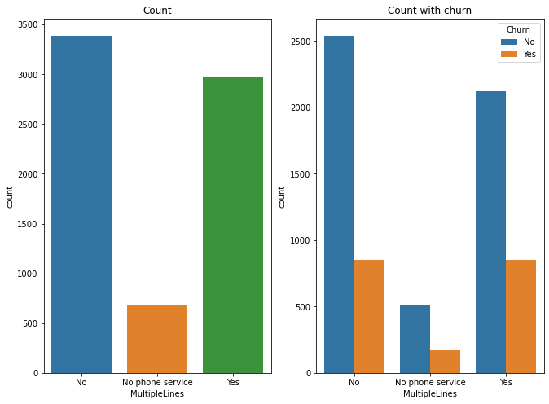

```python
plt.subplot(1,2,1)
sns.countplot(x = c[4],data = data3)
plt.title('Count')

plt.subplot(1,2,2)
sns.countplot(x = c[4],data = data3,hue = 'Churn')
plt.title('Count with churn')
plt.show()
```

**Note:** Equal ratio btw people who have multiple lines and dont , but dont have any phone services have less count in churing or has churned less

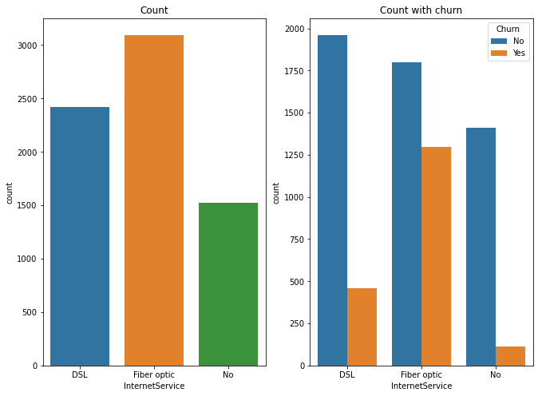

```python
plt.subplot(1,2,1)
sns.countplot(x = c[5],data = data3)
plt.title('Count')

plt.subplot(1,2,2)
sns.countplot(x = c[5],data = data3,hue = 'Churn')
plt.title('Count with churn')
plt.show()
```

**Note:** People who have Fibre optic internet service has churned more then DSL

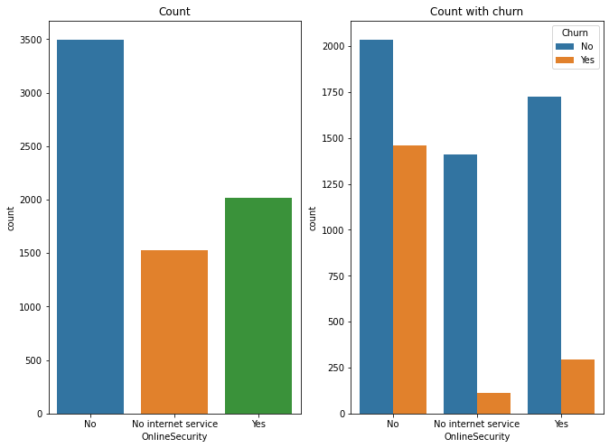

```python
plt.subplot(1,2,1)
sns.countplot(x = c[6],data = data3)
plt.title('Count')

plt.subplot(1,2,2)
sns.countplot(x = c[6],data = data3,hue = 'Churn')
plt.title('Count with churn')
plt.show()
```

**Note:** People those dont have online security has churn most most when compare dto those ho have it

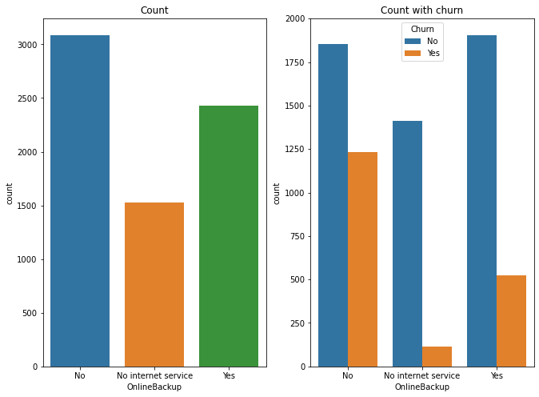

```python
plt.subplot(1,2,1)
sns.countplot(x = c[7],data = data3)
plt.title('Count')

plt.subplot(1,2,2)
sns.countplot(x = c[7],data = data3,hue = 'Churn')
plt.title('Count with churn')
plt.show()
```

**Note:** People those who dont have Online line backup has churned more than those who does

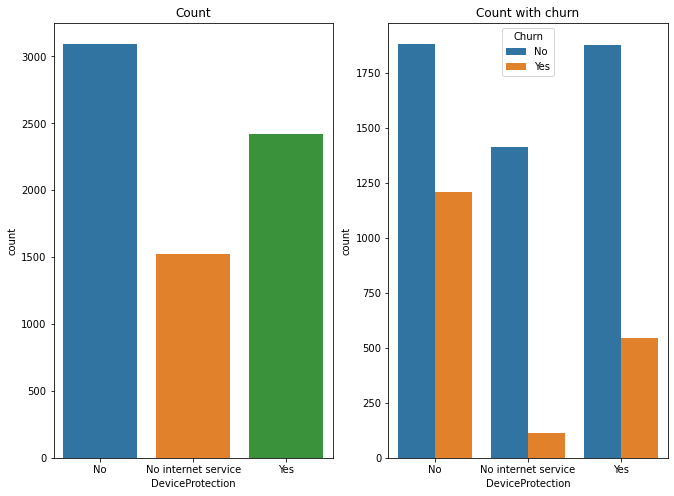

```python
plt.subplot(1,2,1)
sns.countplot(x = c[8],data = data3)
plt.title('Count')

plt.subplot(1,2,2)
sns.countplot(x = c[8],data = data3,hue = 'Churn')
plt.title('Count with churn')
plt.show()
```

**Note:** People those who dont have Device protection has churned more than those who does

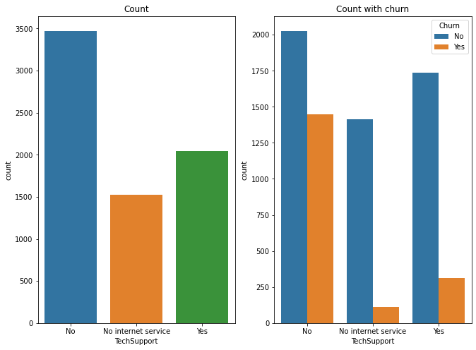

```python
plt.subplot(1,2,1)
sns.countplot(x = c[9],data = data3)
plt.title('Count')

plt.subplot(1,2,2)
sns.countplot(x = c[9],data = data3,hue = 'Churn')
plt.title('Count with churn')
plt.show()
```

**Note:** People those who dont have Tech support has churned more than those who does

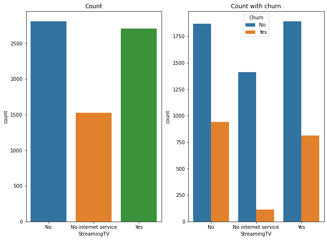

```python
plt.subplot(1,2,1)
sns.countplot(x = c[10],data = data3)
plt.title('Count')

plt.subplot(1,2,2)
sns.countplot(x = c[10],data = data3,hue = 'Churn')
plt.title('Count with churn')
plt.show()
```

**Note:** People those who dont have Streaming tv has churned more than those who does

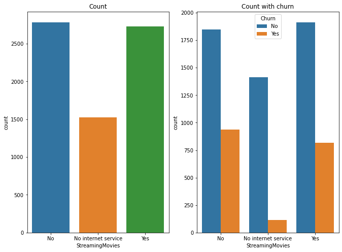

```python
plt.subplot(1,2,1)
sns.countplot(x = c[11],data = data3)
plt.title('Count')

plt.subplot(1,2,2)
sns.countplot(x = c[11],data = data3,hue = 'Churn')
plt.title('Count with churn')
plt.show()
```

**Note:** People those who dont have Stream movies has churned more than those who does

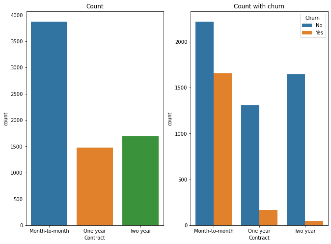

```python
plt.subplot(1,2,1)
sns.countplot(x = c[12],data = data3)
plt.title('Count')

plt.subplot(1,2,2)
sns.countplot(x = c[12],data = data3,hue = 'Churn')
plt.title('Count with churn')
plt.show()
```

**Note:** People those who have month to month contract has churned more than those who have years

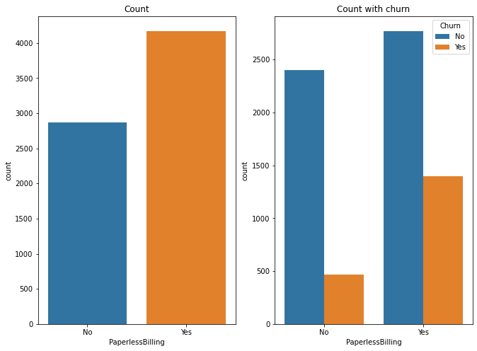

```python
plt.subplot(1,2,1)
sns.countplot(x = c[13],data = data3)
plt.title('Count')

plt.subplot(1,2,2)
sns.countplot(x = c[13],data = data3,hue = 'Churn')
plt.title('Count with churn')
plt.show()
```

**Note:** People those who have paperless billing has churned more than those who does dont

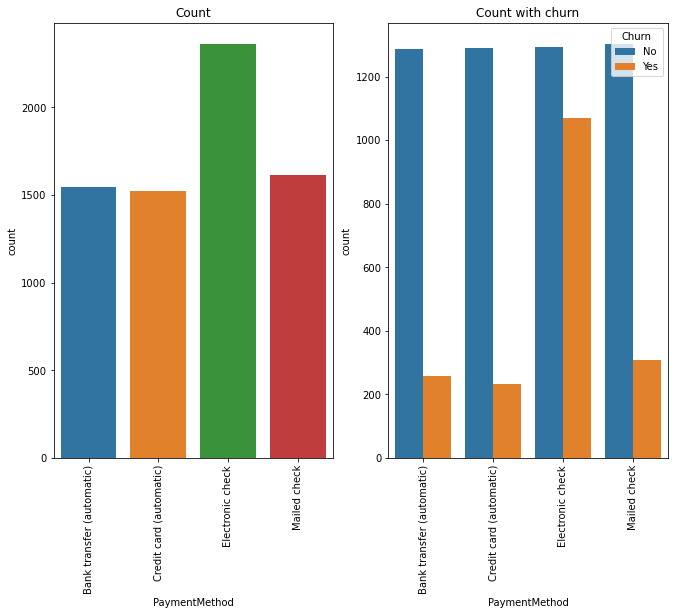

```python
plt.subplot(1,2,1)
sns.countplot(x = c[14],data = data3)
plt.title('Count')
plt.xticks(rotation = 90)

plt.subplot(1,2,2)
sns.countplot(x = c[14],data = data3,hue = 'Churn')
plt.title('Count with churn')
plt.xticks(rotation = 90)
plt.show()
```

**Note:** People those who have checks as payment method has churned more than those who have automatic .In checks also those who have Electronic check has higher count of churns

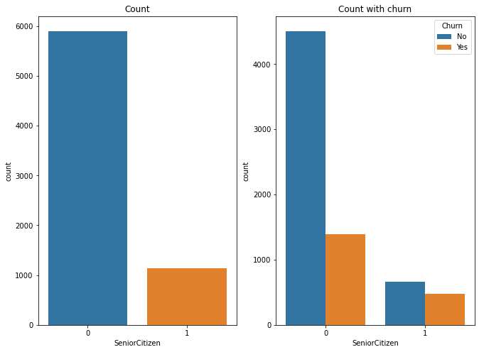

```python
plt.subplot(1,2,1)
sns.countplot(x = 'SeniorCitizen',data = data3)
plt.title('Count')

plt.subplot(1,2,2)
sns.countplot(x = 'SeniorCitizen',data = data3,hue = 'Churn')
plt.title('Count with churn')
plt.show()
```

**Note:** People those who are senior citizen has churned more when compared those who are not

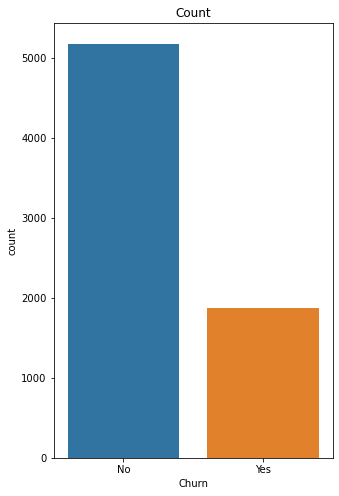

```python
# count of churns
plt.subplot(1,2,1)
sns.countplot(x = c[15],data = data3)
plt.title('Count')
```

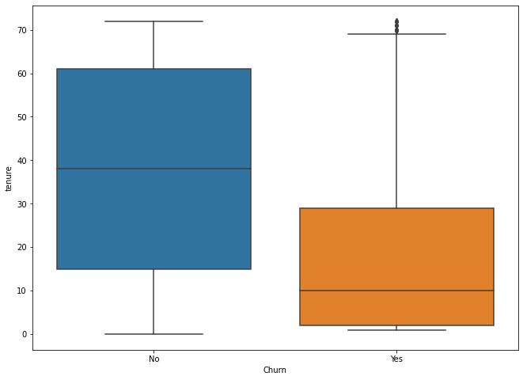

```python
sns.boxplot(y = 'tenure',x = 'Churn',data = data3,)
plt.show()
```

**Note:** People those who have less tenure has churned more when compared those who have more

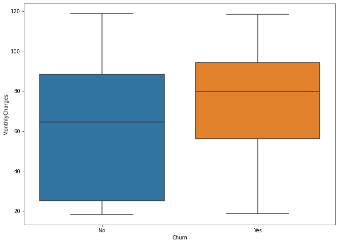

```python
sns.boxplot(y = 'MonthlyCharges',x = 'Churn',data = data3,)
plt.show()
```

**Note:** People those who have more montlycharges has churned more when compared those who have less

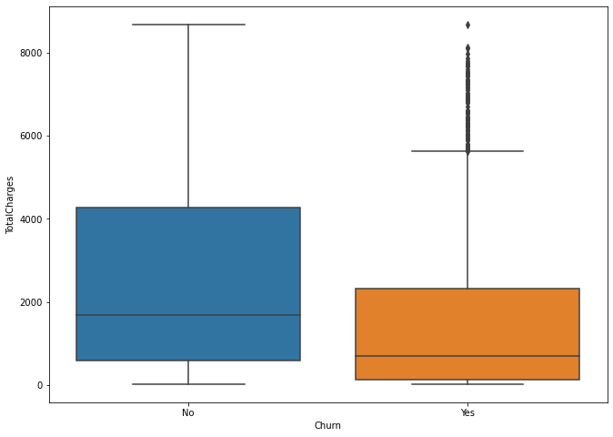

```python
sns.boxplot(y = 'TotalCharges',x = 'Churn',data = data3,)
plt.show()
```

**Note:** People those who have less totalcharges has churned more when compared those who have more

```python
num_corr = data3[['tenure','MonthlyCharges','TotalCharges']].corr()
```

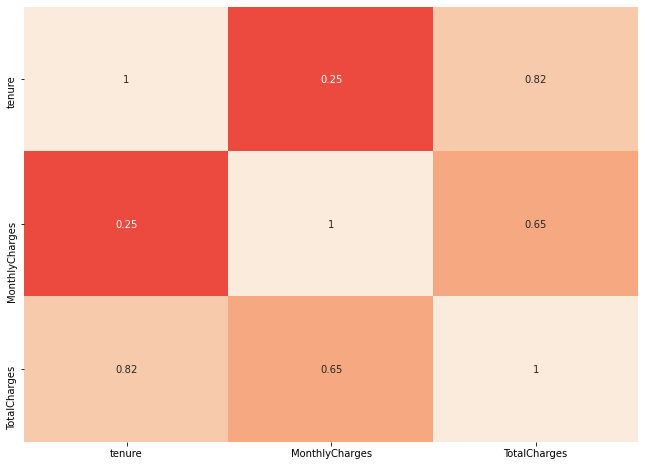

```python
sns.heatmap(num_corr,vmin = -1,vmax = 1,cbar = False,annot = True)
plt.show()
```

1. Tenure and Totalcharges are 82% postively ocrrelated.
2. Totalcharges and montlycharges are 65% postively coreelated

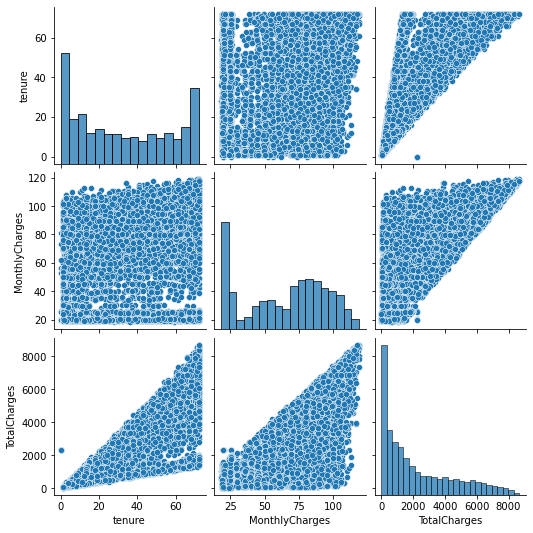

```python
sns.pairplot(x_vars = ['tenure','MonthlyCharges','TotalCharges'],y_vars = ['tenure','MonthlyCharges','TotalCharges'],data = data3)
plt.show()
```

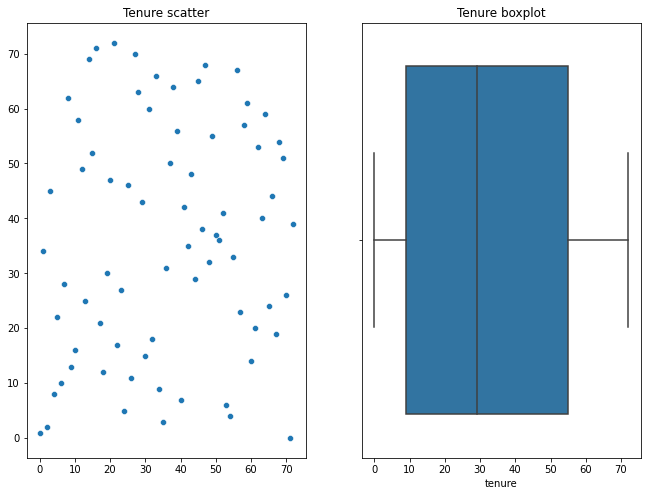

```python
# checking for outliers using boxplot and scatter
plt.subplot(1,2,1)
sns.scatterplot(y = data3['tenure'].unique(),x  =np.arange(len(data3['tenure'].unique())))
plt.title('Tenure scatter')

plt.subplot(1,2,2)
sns.boxplot(x = 'tenure',data = data3,hue = 'Churn')
plt.title('Tenure boxplot')
plt.show()
```

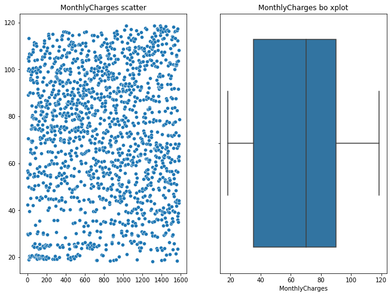

```python
plt.subplot(1,2,1)
sns.scatterplot(y = data3['MonthlyCharges'].unique(),x  =np.arange(len(data3['MonthlyCharges'].unique())))
plt.title('MonthlyCharges scatter')

plt.subplot(1,2,2)
sns.boxplot(x = 'MonthlyCharges',data = data3,hue = 'Churn')
plt.title('MonthlyCharges bo xplot')
plt.show()
```

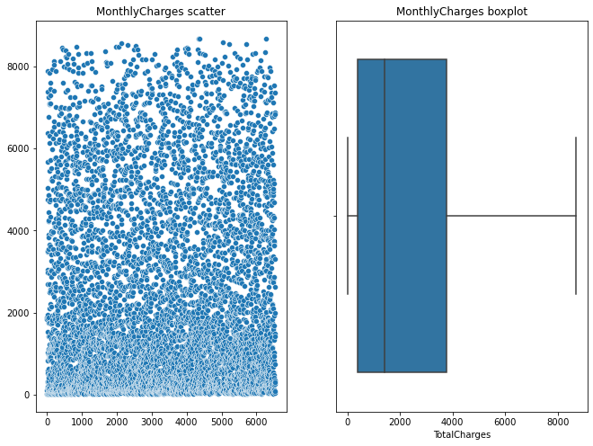

```python
plt.subplot(1,2,1)
sns.scatterplot(y = data3['TotalCharges'].unique(),x  =np.arange(len(data3['TotalCharges'].unique())))
plt.title('MonthlyCharges scatter')

plt.subplot(1,2,2)
sns.boxplot(x = 'TotalCharges',data = data3,hue = 'Churn')
plt.title('MonthlyCharges boxplot')
plt.show()
```

### 4. Data pre-processing:

```python
X = data3.drop('Churn',axis = 1)
y  =data3.Churn
```

```python
X.head()
```

|  | gender | SeniorCitizen | Partner | Dependents | tenure | PhoneService | MultipleLines | InternetService | OnlineSecurity | OnlineBackup | DeviceProtection | TechSupport | StreamingTV | StreamingMovies | Contract | PaperlessBilling | PaymentMethod | MonthlyCharges | TotalCharges |
| --- | --- | --- | --- | --- | --- | --- | --- | --- | --- | --- | --- | --- | --- | --- | --- | --- | --- | --- | --- |
| 0 | Female | 0 | Yes | No | 1 | No | No phone service | DSL | No | Yes | No | No | No | No | Month-to-month | Yes | Electronic check | 29.85 | 29.85 |
| 1 | Male | 0 | No | No | 34 | Yes | No | DSL | Yes | No | Yes | No | No | No | One year | No | Mailed check | 56.95 | 1889.50 |
| 2 | Male | 0 | No | No | 2 | Yes | No | DSL | Yes | Yes | No | No | No | No | Month-to-month | Yes | Mailed check | 53.85 | 108.15 |
| 3 | Male | 0 | No | No | 45 | No | No phone service | DSL | Yes | No | Yes | Yes | No | No | One year | No | Bank transfer (automatic) | 42.30 | 1840.75 |
| 4 | Female | 0 | No | No | 2 | Yes | No | Fiber optic | No | No | No | No | No | No | Month-to-month | Yes | Electronic check | 70.70 | 151.65 |

```python
y
```

```
0        No
1        No
2       Yes
3        No
4       Yes
       ...
7038     No
7039     No
7040     No
7041    Yes
7042     No
Name: Churn, Length: 7043, dtype: category
Categories (2, object): ['No', 'Yes']
```

```python
#using one hot encoding
le_cols = []
ohe_cols = []
for x in cat_cols[:-1]:
    if len(data3[x].unique()) <= 2:
        le_cols.append(x)
    else:
        ohe_cols.append(x)
```

```python
print('le_cols:{}'.format(le_cols))
print('ohee_cols:{}'.format(ohe_cols))
```

```
le_cols:['gender', 'Partner', 'Dependents', 'PhoneService', 'PaperlessBilling']
ohee_cols:['MultipleLines', 'InternetService', 'OnlineSecurity', 'OnlineBackup', 'DeviceProtection', 'TechSupport', 'StreamingTV', 'StreamingMovies', 'Contract', 'PaymentMethod']
```

```python
# label encoding
X_encoded = X.copy()
le = LabelEncoder()
for x in le_cols:
    le.fit(X[x])
    X_encoded[x] = le.transform(X[x])
```

```python
X_encoded.head()
```

|  | gender | SeniorCitizen | Partner | Dependents | tenure | PhoneService | MultipleLines | InternetService | OnlineSecurity | OnlineBackup | DeviceProtection | TechSupport | StreamingTV | StreamingMovies | Contract | PaperlessBilling | PaymentMethod | MonthlyCharges | TotalCharges |
| --- | --- | --- | --- | --- | --- | --- | --- | --- | --- | --- | --- | --- | --- | --- | --- | --- | --- | --- | --- |
| 0 | 0 | 0 | 1 | 0 | 1 | 0 | No phone service | DSL | No | Yes | No | No | No | No | Month-to-month | 1 | Electronic check | 29.85 | 29.85 |
| 1 | 1 | 0 | 0 | 0 | 34 | 1 | No | DSL | Yes | No | Yes | No | No | No | One year | 0 | Mailed check | 56.95 | 1889.50 |
| 2 | 1 | 0 | 0 | 0 | 2 | 1 | No | DSL | Yes | Yes | No | No | No | No | Month-to-month | 1 | Mailed check | 53.85 | 108.15 |
| 3 | 1 | 0 | 0 | 0 | 45 | 0 | No phone service | DSL | Yes | No | Yes | Yes | No | No | One year | 0 | Bank transfer (automatic) | 42.30 | 1840.75 |
| 4 | 0 | 0 | 0 | 0 | 2 | 1 | No | Fiber optic | No | No | No | No | No | No | Month-to-month | 1 | Electronic check | 70.70 | 151.65 |

```python
#onehot encoding
ohe = OneHotEncoder(drop = 'first')
ohe.fit(X_encoded[ohe_cols])
f= ohe.transform(X_encoded[ohe_cols]).toarray()
print(f.shape)
features = ohe.get_feature_names(ohe_cols)
```

```
(7043, 21)
```

```python
f = f.astype(int)
```

```python
ohe_df = pd.DataFrame(f)
ohe_df.columns = features
ohe_df
```

|  | MultipleLines_No phone service | MultipleLines_Yes | InternetService_Fiber optic | InternetService_No | OnlineSecurity_No internet service | OnlineSecurity_Yes | OnlineBackup_No internet service | OnlineBackup_Yes | DeviceProtection_No internet service | DeviceProtection_Yes | ... | TechSupport_Yes | StreamingTV_No internet service | StreamingTV_Yes | StreamingMovies_No internet service | StreamingMovies_Yes | Contract_One year | Contract_Two year | PaymentMethod_Credit card (automatic) | PaymentMethod_Electronic check | PaymentMethod_Mailed check |
| --- | --- | --- | --- | --- | --- | --- | --- | --- | --- | --- | --- | --- | --- | --- | --- | --- | --- | --- | --- | --- | --- |
| 0 | 1 | 0 | 0 | 0 | 0 | 0 | 0 | 1 | 0 | 0 | ... | 0 | 0 | 0 | 0 | 0 | 0 | 0 | 0 | 1 | 0 |
| 1 | 0 | 0 | 0 | 0 | 0 | 1 | 0 | 0 | 0 | 1 | ... | 0 | 0 | 0 | 0 | 0 | 1 | 0 | 0 | 0 | 1 |
| 2 | 0 | 0 | 0 | 0 | 0 | 1 | 0 | 1 | 0 | 0 | ... | 0 | 0 | 0 | 0 | 0 | 0 | 0 | 0 | 0 | 1 |
| 3 | 1 | 0 | 0 | 0 | 0 | 1 | 0 | 0 | 0 | 1 | ... | 1 | 0 | 0 | 0 | 0 | 1 | 0 | 0 | 0 | 0 |
| 4 | 0 | 0 | 1 | 0 | 0 | 0 | 0 | 0 | 0 | 0 | ... | 0 | 0 | 0 | 0 | 0 | 0 | 0 | 0 | 1 | 0 |
| ... | ... | ... | ... | ... | ... | ... | ... | ... | ... | ... | ... | ... | ... | ... | ... | ... | ... | ... | ... | ... | ... |
| 7038 | 0 | 1 | 0 | 0 | 0 | 1 | 0 | 0 | 0 | 1 | ... | 1 | 0 | 1 | 0 | 1 | 1 | 0 | 0 | 0 | 1 |
| 7039 | 0 | 1 | 1 | 0 | 0 | 0 | 0 | 1 | 0 | 1 | ... | 0 | 0 | 1 | 0 | 1 | 1 | 0 | 1 | 0 | 0 |
| 7040 | 1 | 0 | 0 | 0 | 0 | 1 | 0 | 0 | 0 | 0 | ... | 0 | 0 | 0 | 0 | 0 | 0 | 0 | 0 | 1 | 0 |
| 7041 | 0 | 1 | 1 | 0 | 0 | 0 | 0 | 0 | 0 | 0 | ... | 0 | 0 | 0 | 0 | 0 | 0 | 0 | 0 | 0 | 1 |
| 7042 | 0 | 0 | 1 | 0 | 0 | 1 | 0 | 0 | 0 | 1 | ... | 1 | 0 | 1 | 0 | 1 | 0 | 1 | 0 | 0 | 0 |

7043 rows × 21 columns

```python
X_encoded = pd.concat([X_encoded,ohe_df],axis = 1)
print('\n',X_encoded.columns)
X_encoded.drop(ohe_cols,axis = 1,inplace = True)
print('\n',X_encoded.columns)
```

```
 Index(['gender', 'SeniorCitizen', 'Partner', 'Dependents', 'tenure',
       'PhoneService', 'MultipleLines', 'InternetService', 'OnlineSecurity',
       'OnlineBackup', 'DeviceProtection', 'TechSupport', 'StreamingTV',
       'StreamingMovies', 'Contract', 'PaperlessBilling', 'PaymentMethod',
       'MonthlyCharges', 'TotalCharges', 'MultipleLines_No phone service',
       'MultipleLines_Yes', 'InternetService_Fiber optic',
       'InternetService_No', 'OnlineSecurity_No internet service',
       'OnlineSecurity_Yes', 'OnlineBackup_No internet service',
       'OnlineBackup_Yes', 'DeviceProtection_No internet service',
       'DeviceProtection_Yes', 'TechSupport_No internet service',
       'TechSupport_Yes', 'StreamingTV_No internet service', 'StreamingTV_Yes',
       'StreamingMovies_No internet service', 'StreamingMovies_Yes',
       'Contract_One year', 'Contract_Two year',
       'PaymentMethod_Credit card (automatic)',
       'PaymentMethod_Electronic check', 'PaymentMethod_Mailed check'],
      dtype='object')

 Index(['gender', 'SeniorCitizen', 'Partner', 'Dependents', 'tenure',
       'PhoneService', 'PaperlessBilling', 'MonthlyCharges', 'TotalCharges',
       'MultipleLines_No phone service', 'MultipleLines_Yes',
       'InternetService_Fiber optic', 'InternetService_No',
       'OnlineSecurity_No internet service', 'OnlineSecurity_Yes',
       'OnlineBackup_No internet service', 'OnlineBackup_Yes',
       'DeviceProtection_No internet service', 'DeviceProtection_Yes',
       'TechSupport_No internet service', 'TechSupport_Yes',
       'StreamingTV_No internet service', 'StreamingTV_Yes',
       'StreamingMovies_No internet service', 'StreamingMovies_Yes',
       'Contract_One year', 'Contract_Two year',
       'PaymentMethod_Credit card (automatic)',
       'PaymentMethod_Electronic check', 'PaymentMethod_Mailed check'],
      dtype='object')
```

```python
X_encoded.head()
```

|  | gender | SeniorCitizen | Partner | Dependents | tenure | PhoneService | PaperlessBilling | MonthlyCharges | TotalCharges | MultipleLines_No phone service | ... | TechSupport_Yes | StreamingTV_No internet service | StreamingTV_Yes | StreamingMovies_No internet service | StreamingMovies_Yes | Contract_One year | Contract_Two year | PaymentMethod_Credit card (automatic) | PaymentMethod_Electronic check | PaymentMethod_Mailed check |
| --- | --- | --- | --- | --- | --- | --- | --- | --- | --- | --- | --- | --- | --- | --- | --- | --- | --- | --- | --- | --- | --- |
| 0 | 0 | 0 | 1 | 0 | 1 | 0 | 1 | 29.85 | 29.85 | 1 | ... | 0 | 0 | 0 | 0 | 0 | 0 | 0 | 0 | 1 | 0 |
| 1 | 1 | 0 | 0 | 0 | 34 | 1 | 0 | 56.95 | 1889.50 | 0 | ... | 0 | 0 | 0 | 0 | 0 | 1 | 0 | 0 | 0 | 1 |
| 2 | 1 | 0 | 0 | 0 | 2 | 1 | 1 | 53.85 | 108.15 | 0 | ... | 0 | 0 | 0 | 0 | 0 | 0 | 0 | 0 | 0 | 1 |
| 3 | 1 | 0 | 0 | 0 | 45 | 0 | 0 | 42.30 | 1840.75 | 1 | ... | 1 | 0 | 0 | 0 | 0 | 1 | 0 | 0 | 0 | 0 |
| 4 | 0 | 0 | 0 | 0 | 2 | 1 | 1 | 70.70 | 151.65 | 0 | ... | 0 | 0 | 0 | 0 | 0 | 0 | 0 | 0 | 1 | 0 |

5 rows × 30 columns

```python
X_encoded.info()
```

```
<class 'pandas.core.frame.DataFrame'>
RangeIndex: 7043 entries, 0 to 7042
Data columns (total 30 columns):
 #   Column                                 Non-Null Count  Dtype
---  ------                                 --------------  -----
 0   gender                                 7043 non-null   int32
 1   SeniorCitizen                          7043 non-null   int64
 2   Partner                                7043 non-null   int32
 3   Dependents                             7043 non-null   int32
 4   tenure                                 7043 non-null   int64
 5   PhoneService                           7043 non-null   int32
 6   PaperlessBilling                       7043 non-null   int32
 7   MonthlyCharges                         7043 non-null   float64
 8   TotalCharges                           7043 non-null   float64
 9   MultipleLines_No phone service         7043 non-null   int32
```

[output cut: 22 more lines]

```python
#scaling tenture,monthlycharges and total charges
scaler = MinMaxScaler()
X_encoded[['tenure','MonthlyCharges','TotalCharges']] = scaler.fit_transform(X_encoded[['tenure','MonthlyCharges','TotalCharges']])
X_encoded
```

|  | gender | SeniorCitizen | Partner | Dependents | tenure | PhoneService | PaperlessBilling | MonthlyCharges | TotalCharges | MultipleLines_No phone service | ... | TechSupport_Yes | StreamingTV_No internet service | StreamingTV_Yes | StreamingMovies_No internet service | StreamingMovies_Yes | Contract_One year | Contract_Two year | PaymentMethod_Credit card (automatic) | PaymentMethod_Electronic check | PaymentMethod_Mailed check |
| --- | --- | --- | --- | --- | --- | --- | --- | --- | --- | --- | --- | --- | --- | --- | --- | --- | --- | --- | --- | --- | --- |
| 0 | 0 | 0 | 1 | 0 | 0.013889 | 0 | 1 | 0.115423 | 0.001275 | 1 | ... | 0 | 0 | 0 | 0 | 0 | 0 | 0 | 0 | 1 | 0 |
| 1 | 1 | 0 | 0 | 0 | 0.472222 | 1 | 0 | 0.385075 | 0.215867 | 0 | ... | 0 | 0 | 0 | 0 | 0 | 1 | 0 | 0 | 0 | 1 |
| 2 | 1 | 0 | 0 | 0 | 0.027778 | 1 | 1 | 0.354229 | 0.010310 | 0 | ... | 0 | 0 | 0 | 0 | 0 | 0 | 0 | 0 | 0 | 1 |
| 3 | 1 | 0 | 0 | 0 | 0.625000 | 0 | 0 | 0.239303 | 0.210241 | 1 | ... | 1 | 0 | 0 | 0 | 0 | 1 | 0 | 0 | 0 | 0 |
| 4 | 0 | 0 | 0 | 0 | 0.027778 | 1 | 1 | 0.521891 | 0.015330 | 0 | ... | 0 | 0 | 0 | 0 | 0 | 0 | 0 | 0 | 1 | 0 |
| ... | ... | ... | ... | ... | ... | ... | ... | ... | ... | ... | ... | ... | ... | ... | ... | ... | ... | ... | ... | ... | ... |
| 7038 | 1 | 0 | 1 | 1 | 0.333333 | 1 | 1 | 0.662189 | 0.227521 | 0 | ... | 1 | 0 | 1 | 0 | 1 | 1 | 0 | 0 | 0 | 1 |
| 7039 | 0 | 0 | 1 | 1 | 1.000000 | 1 | 1 | 0.845274 | 0.847461 | 0 | ... | 0 | 0 | 1 | 0 | 1 | 1 | 0 | 1 | 0 | 0 |
| 7040 | 0 | 0 | 1 | 1 | 0.152778 | 0 | 1 | 0.112935 | 0.037809 | 1 | ... | 0 | 0 | 0 | 0 | 0 | 0 | 0 | 0 | 1 | 0 |
| 7041 | 1 | 1 | 1 | 0 | 0.055556 | 1 | 1 | 0.558706 | 0.033210 | 0 | ... | 0 | 0 | 0 | 0 | 0 | 0 | 0 | 0 | 0 | 1 |
| 7042 | 1 | 0 | 0 | 0 | 0.916667 | 1 | 1 | 0.869652 | 0.787641 | 0 | ... | 1 | 0 | 1 | 0 | 1 | 0 | 1 | 0 | 0 | 0 |

7043 rows × 30 columns

```python
# Spliting data into train nd test 80% :20% ratio
X_train,X_test,y_train,y_test = train_test_split(X_encoded,le.fit_transform(y),test_size = 0.2,random_state =1)
```

```python
print(X_train.shape)
print('\n',X_test.shape)
```

```
(5634, 30)

 (1409, 30)
```